# Neuralnet Tutorial

## O conjunto de dados

Vamos usar o conjunto de dados de Boston do pacote MASS. O conjunto de dados de Boston é uma coleção de dados sobre valores de moradia nos subúrbios de Boston. Nosso objetivo é prever o valor médio das casas ocupadas pelo proprietário (medv) usando todas as outras variáveis contínuas disponíveis.

```r
set.seed(500)
library(MASS)
data = Boston
```

Primeiro, precisamos verificar se não há dados faltantes (NA), caso contrário, precisamos corrigir o conjunto de dados ( inputação ou remoção do case).

```r
apply(data,2,function(x) sum(is.na(x)))
```

```
   crim      zn   indus    chas     nox      rm     age     dis     rad     tax ptratio   black   lstat    medv
      0       0       0       0       0       0       0       0       0       0       0       0       0       0
```

Não há dados ausentes. Seguimos com a divisão do conjunto de dados em um conjunto de treinamento e outro de testes, depois ajustaremos um modelo de regressão linear e testaremos no conjunto de testes. Note que usaremos a função gml() ao invés do lm(), isso se será útil na validação cruzada do modelo linear.

```r
#
index = sample(1:nrow(data),round(0.75*nrow(data)))
# treinamento
train = data[index,]
# teste
test = data[-index,]
# ajuste modelo linear
lm.fit = glm(medv~., data=train)
summary(lm.fit)
```

```
Call:
glm(formula = medv ~ ., data = train)

Deviance Residuals:
     Min        1Q    Median        3Q       Max
-14.9143   -2.8607   -0.5244    1.5242   25.0004

Coefficients:
              Estimate Std. Error t value Pr(>|t|)
(Intercept)  43.469681   6.099347   7.127 5.50e-12 ***
crim         -0.105439   0.057095  -1.847 0.065596 .
zn            0.044347   0.015974   2.776 0.005782 **
indus         0.024034   0.071107   0.338 0.735556
chas          2.596028   1.089369   2.383 0.017679 *
nox         -22.336623   4.572254  -4.885 1.55e-06 ***
rm            3.538957   0.472374   7.492 5.15e-13 ***
age           0.016976   0.015088   1.125 0.261291
dis          -1.570970   0.235280  -6.677 9.07e-11 ***
rad           0.400502   0.085475   4.686 3.94e-06 ***
tax          -0.015165   0.004599  -3.297 0.001072 **
ptratio      -1.147046   0.155702  -7.367 1.17e-12 ***
black         0.010338   0.003077   3.360 0.000862 ***
lstat        -0.524957   0.056899  -9.226  < 2e-16 ***
---
Signif. codes:  0 *** 0.001 ** 0.01 * 0.05 . 0.1   1

(Dispersion parameter for gaussian family taken to be 23.26491)

    Null deviance: 33642  on 379  degrees of freedom
Residual deviance:  8515  on 366  degrees of freedom
AIC: 2290

Number of Fisher Scoring iterations: 2
```

```r
pr.lm = predict(lm.fit,test)
MSE.lm = sum((pr.lm - test$medv)^2)/nrow(test)
```

Como estamos lidando com um problema de regressão, vamos usar o erro quadrático médio (MSE) como uma medida de qualidade de ajuste.

## Ajustando uma rede neural

As redes neurais não são tão fáceis de treinar e ajustar. Antes de iniciar, é preciso preparar os dados.

De forma geral os dados devem ser normalizados. Não há como especificar esta importância, mas pode afetar a análise dificultando o treinamento (na maioria das vezes o algoritmo não convergirá antes do número de iterações máximas permitidas). Há diversos métodos:z-normalização, escala min-max, etc.. Aqui usaremos o método min-max para redimensionar os dados no intervalo [0,1]. Normalmente, o escalonamento nos intervalos [0,1] ou [-1,1] tende a dar melhores resultados.

```r
maxs = apply(data, 2, max)
mins = apply(data, 2, min)
scaled = as.data.frame(scale(data, center = mins, scale = maxs - mins))
train_ = scaled[index,]
test_ = scaled[-index,]
```

Observe que a escala retorna uma matriz que precisa ser transformada em um data.frame.

## Parametros

Não há uma regra fixa sobre quantas camadas e neurônios deva ser usada, embora existam algumas regras genéricas. Geralmente, uma camada oculta é suficiente para um vasto número de aplicações. Quanto ao número de neurônios, ele deve estar entre o tamanho da camada de entrada e o tamanho da camada de saída. Geralmente usa-se 2/3 do tamanho da entrada. É aconselhável, testar varios moelos, já que não há garantia de que qualquer uma dessas regras se adapte melhor ao seu problema. Como este é um exemplo de brinquedo, vamos usar duas camadas ocultas com essa configuração: $13:5:3:1$. A camada de entrada tamanho 13 (13 variáveis de entradas), as duas camadas ocultas com 5 e 3 neurônios e a camada de saída com tamanho um, já que estamos fazendo regressão. Vamos encaixar na net:

```r
library(neuralnet)
n = names(train_)
f = as.formula(paste("medv ~", paste(n[!n %in% "medv"], collapse = " + ")))
nn = neuralnet(f,data=train_,hidden=c(5,3),linear.output=T)
```

Notas:

- Por alguma razão, a fórmula y ~. não é aceito na função neuralnet(). Você precisa primeiro escrever a fórmula e depois passá-la como um argumento na função de ajuste.
- O argumento *hidden* aceita um vetor onde o comprimento representa o número de camadas escondidas e os valores representam o número de neurônios para cada camada.
- O argumento *linear.output* é usado para especificar se queremos fazer regressão (*linear.output = TRUE*) ou classificação (*linear.output = FALSE*)

O pacote *neuralnet* fornece uma boa ferramenta para plotar o modelo

Esta é a representação gráfica do modelo com os pesos em cada conexão:

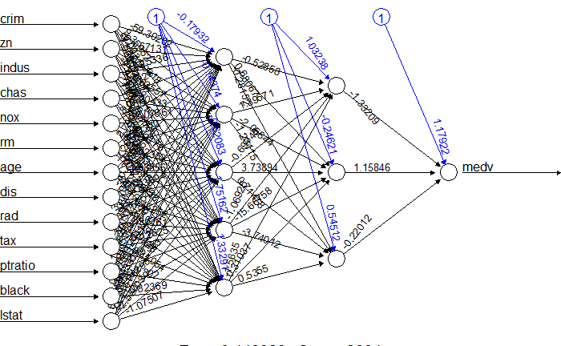

```r
plot(nn)
```

As linhas pretas mostram as conexões entre cada camada e os pesos em cada conexão, enquanto as linhas azuis mostram o termo de polarização adicionado em cada etapa. O viés pode ser pensado como o intercepto de um modelo linear. A rede é essencialmente uma caixa preta, então não podemos dizer muito sobre o ajuste dos pesos e do modelo. Basta dizer que o algoritmo de treinamento convergiu e, portanto, o modelo está pronto para ser usado.

## Previsão de “medv” usando a rede neural

Agora podemos tentar prever os valores para o conjunto de testes e calcular o MSE. Lembre-se de que a rede gerará uma previsão normalizada, portanto, precisamos redimensioná-la para fazer uma comparação (ou apenas uma previsão simples).

```r
pr.nn = compute(nn,test_[,1:13])
pr.nn_ = pr.nn$net.result*(max(data$medv)-min(data$medv))+min(data$medv)
test.r = (test_$medv)*(max(data$medv)-min(data$medv))+min(data$medv)
MSE.nn = sum((test.r - pr.nn_)^2)/nrow(test_)
```

Comparando os dois MSEs

```r
result=data.frame(lm_MSE=MSE.lm,nn_MSE=MSE.nn)
knitr::kable(result,align = c("c","c"),digits=3)
```

```
| lm_MSE | nn_MSE |
|:------:|:------:|
| 21.63  | 15.752 |
```

```r
#print(paste(MSE.lm,MSE.nn))
```

Aparentemente, a rede está fazendo um trabalho melhor do que o modelo linear na previsão de medv. Mais uma vez, tenha cuidado, porque esse resultado depende da divisão do teste de trem realizada acima. Abaixo, após o enredo visual, vamos realizar uma validação cruzada rápida para ter mais confiança nos resultados. Uma primeira abordagem visual para o desempenho da rede e o modelo linear no conjunto de teste está plotada abaixo

```r
par(mfrow=c(1,2))
plot(test$medv,pr.nn_,col='red',main='Real vs predicted NN',pch=18,cex=0.7)
abline(0,1,lwd=2)
```

```r
legend('bottomright',legend='NN',pch=18,col='red', bty='n')
plot(test$medv,pr.lm,col='blue',main='Real vs predicted lm',pch=18, cex=0.7)
```

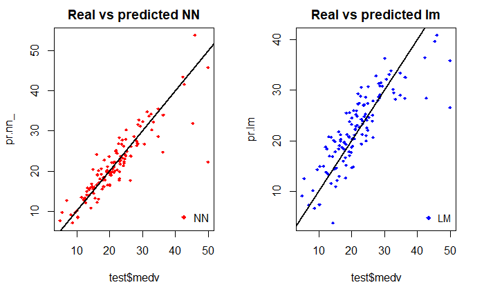

```r
abline(0,1,lwd=2)
legend('bottomright',legend='LM',pch=18,col='blue', bty='n', cex=.95)
```

Podemos ver que as previsões feitas pela rede neural são (em geral) mais concentradas em torno da linha (um alinhamento perfeito com a linha indicaria um MSE de 0 e, portanto, uma previsão perfeita, ideal) do que aquelas feitas por o modelo linear.

Uma comparação visual talvez mais útil é plotada abaixo:

```r
plot(test$medv,pr.nn_,col='red',main='Real vs predicted NN',pch=18,cex=0.7)
points(test$medv,pr.lm,col='blue',pch=18,cex=0.7)
```

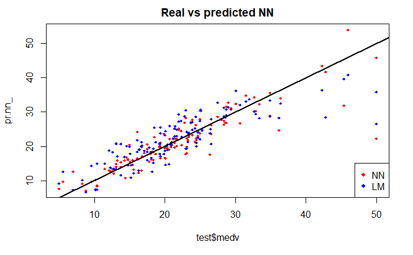

```r
abline(0,1,lwd=2)
legend('bottomright',legend=c('NN','LM'),pch=18,col=c('red','blue'))
```

## Cross Validation (fast)

A validação cruzada é importante na construção de modelos preditivos. Embora existam diferentes tipos de métodos de validação cruzada, a ideia básica é repetir o seguinte processo por um certo tempo:

- Faça a divisão dataset em *test* e *train*
- Ajuste o modelo no conjunto do treinamento
- Teste o modelo no conjunto de teste
- Calcular o erro de previsão
- Repetir o processo $k$ vezes

Vamos implementar uma validação cruzada rápida usando um loop para a rede neural e a função cv.glm() no pacote de inicialização para o modelo linear. Segue o MSE validado com 10 realizações para o modelo linear:

```r
library(boot)
set.seed(200)
lm.fit = glm(medv~.,data=data)
cv.glm(data,lm.fit,K=10)$delta[1]
```

```
[1] 23.83560156
```

Agora com a rede neural. Note que os dados foram divididos em: 90% de conjunto para treinamento e 10% para teste de forma aleatória por 10 vezes.

```r
set.seed(450)
cv.error = NULL
k = 10
library(plyr)
pbar = create_progress_bar('text')
pbar$init(k)
for(i in 1:k){
    index = sample(1:nrow(data),round(0.9*nrow(data)))
    train.cv = scaled[index,]
    test.cv = scaled[-index,]

    nn = neuralnet(f,data=train.cv,hidden=c(5,2),linear.output=T)

    pr.nn = compute(nn,test.cv[,1:13])
    pr.nn = pr.nn$net.result*(max(data$medv)-min(data$medv))+min(data$medv)

    test.cv.r = (test.cv$medv)*(max(data$medv)-min(data$medv))+min(data$medv)

    cv.error[i] = sum((test.cv.r - pr.nn)^2)/nrow(test.cv)

    pbar$step()
}
```

Demora um pouco. Depois, calculamos o MSE médio e plotamos os resultados como um boxplot

```r
cv.error
```

```
 [1] 17.640652805  6.310575067 15.769518577  5.730130820 10.520947119  6.121160840  6.389967211  8.004786424
 [9] 17.369282494  9.412778105
```

```r
mean(cv.error)
```

```
[1] 10.32697995
```

O Boxplot do MSE para o CV na NN:

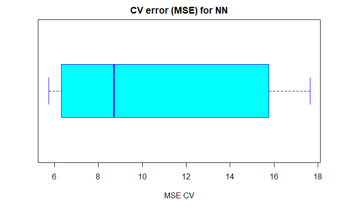

```r
boxplot(cv.error,xlab='MSE CV',col='cyan',
        border='blue',names='CV error (MSE)',
        main='CV error (MSE) for NN',horizontal=TRUE)
```

O MSE médio para a rede neural (10.33) é menor que o do modelo linear, embora pareça haver um certo grau de variação nas MSEs da validação cruzada. Isso pode depender da divisão dos dados ou da inicialização aleatória dos pesos na rede. Ao executar a simulação em diferentes momentos com diferentes sementes, você pode obter uma estimativa pontual mais precisa para o MSE médio.

Uma nota final sobre a interpretabilidade do modelo As redes neurais se assemelham muito a caixas-pretas: explicar seu resultado é muito mais difícil do que explicar o resultado de um modelo mais simples, como um modelo linear. Portanto, dependendo da finalidade do seu trabalho, convém levar em conta esse fator também. Além disso, como você viu acima, um cuidado extra é necessário para ajustar uma rede neural e pequenas mudanças podem levar a resultados diferentes.

https://www.r-bloggers.com/fitting-a-neural-network-in-r-neuralnet-package/